# Rule Trends

Adam Ribaudo

3/28/2020

# Load data

```r
transaction_col = "transaction"
partition_col = "partition"
item_col = "item"
minconf <- .5
minsup <- .03
critical_z <- -1.65 # equates to 95% confidence
confidence_val <- .95
partition_levels <- month.abb

# Functions Require that the df have partition, transaction, and item as columns and that the parameters above are set
df <- read_excel("..\\data\\online_retail_II.xlsx", sheet=1) %>% bind_rows(read_excel("..\\data\\online_retail_II.xlsx", sheet=2)) %>%
  rename(InvoiceNo = Invoice, UnitPrice = Price, CustomerID = `Customer ID`) %>%
  mutate(isRefund = grepl("C", InvoiceNo) | Quantity < 0) %>%
  filter(isRefund == FALSE) %>%
  # Convert datetime to date
  mutate(InvoiceDate = as.Date(InvoiceDate, format = "%m/%d/%Y %H:%M")) %>%
  # Extract month
  mutate(InvoiceYearMonth = paste0(year(InvoiceDate),month(InvoiceDate))) %>%
  # Consider 2010 data only
  filter(grepl("2010",InvoiceYearMonth)) %>%
  mutate(month = month.abb[month(InvoiceDate)])

df_month <- df %>% rename(partition = month, transaction = InvoiceNo, item = StockCode)
results_month <- get_change_mining_results(df_month,minsup=minsup,minconf=minconf,confidence_val=.95)
partitioned_transactions <- results_month$partitioned_transactions
```

# Distribution of Itemset Sizes (2010 Transactions)

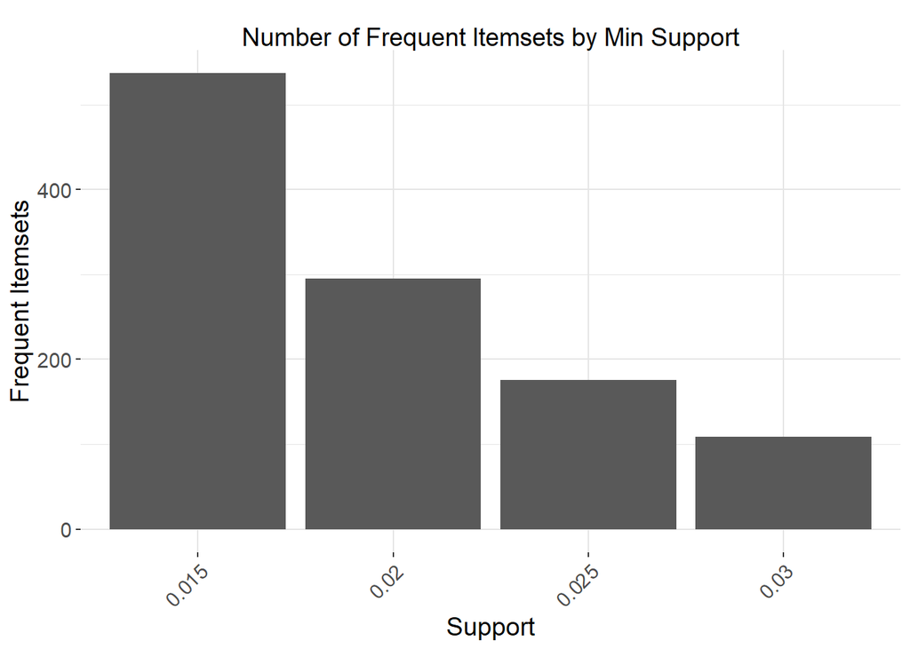

```r
# Explore supports across all time partitions
supports <- c(.015, .02, .025, .03)
global_support_df <- data.frame(support = supports)
global_support_df$frequent_items <- as.vector(sapply(supports,function(x)length(eclat(get_transactions_from_df(df_month), parameter = list(supp = x, minlen=1), control=list(verbose=F)))))

ggplot(global_support_df) + geom_col(aes(x=factor(support),y=frequent_items)) + labs(y="Frequent Itemsets",x="Support",title="Number of Frequent Itemsets by Min Support") + my_theme
```

# Partition Data by Month

## Distance between Months

The heatmap below shows the “distance” between each month as calculated by the Jaccard distance: (1-intersection/union) where intersection and union are comparing frequent itemsets between the 2 months.

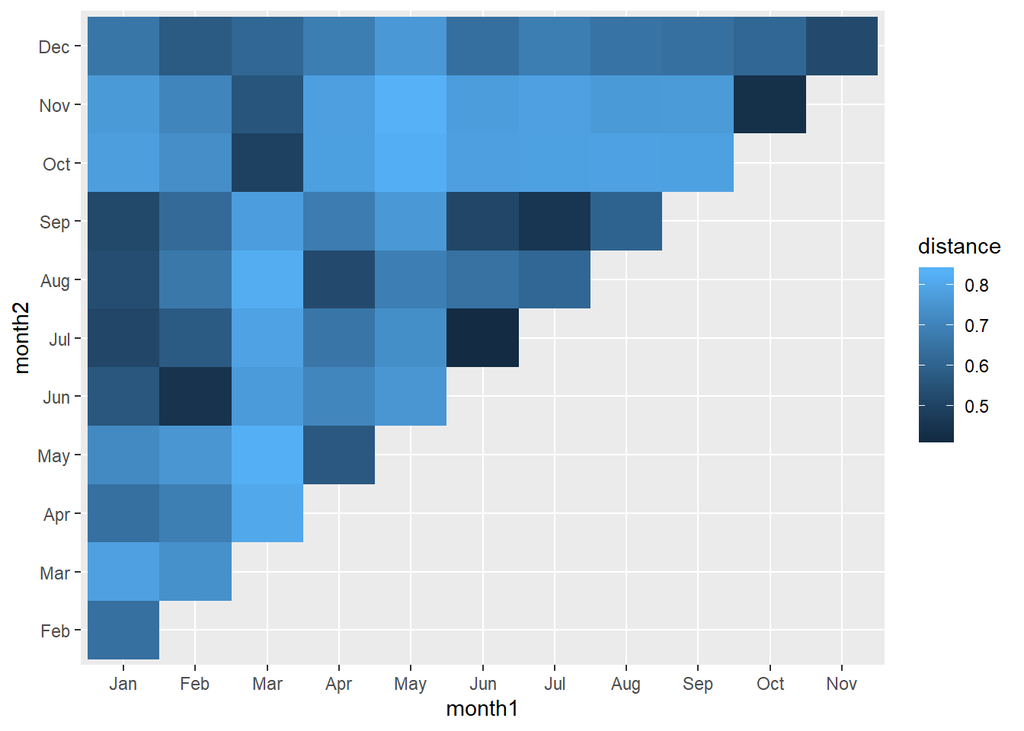

## Itemset size across Months

Each cell is a histogram showing the size of the frequent itemsets (with minsup=0.03) for each month partition. The red line and coloring denote the median for that month.

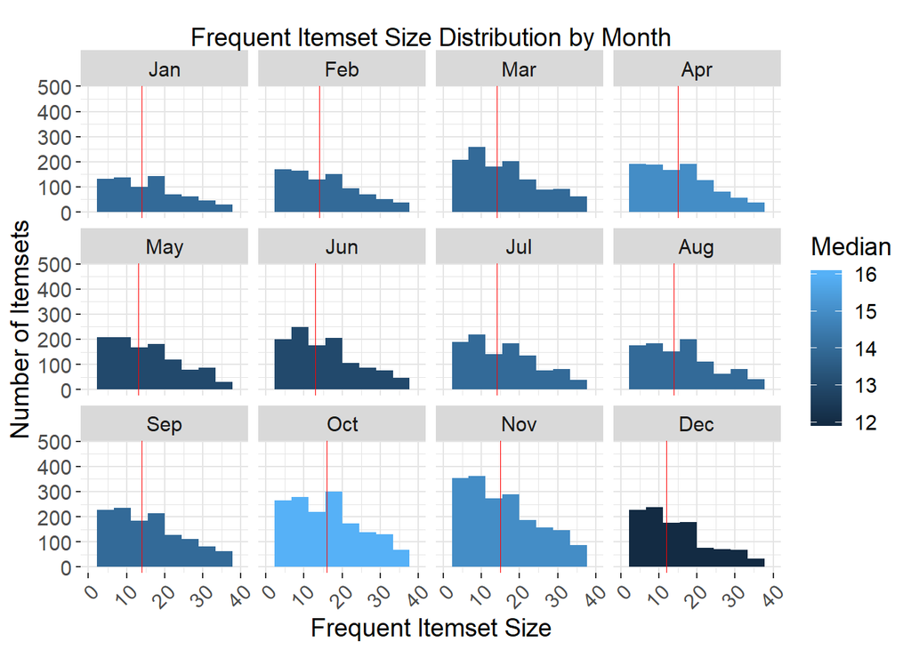

## Rule Counts by Minsup

This chart shows the number of frequent rules, semi stable rules, and stable rules at varying levels of minsup. Ideally, we can set a minsup that yields a small handful of stable rules worth evaluating further.

This shows the value of finding stable rules: they help reduce the number of frequent rules we must consider

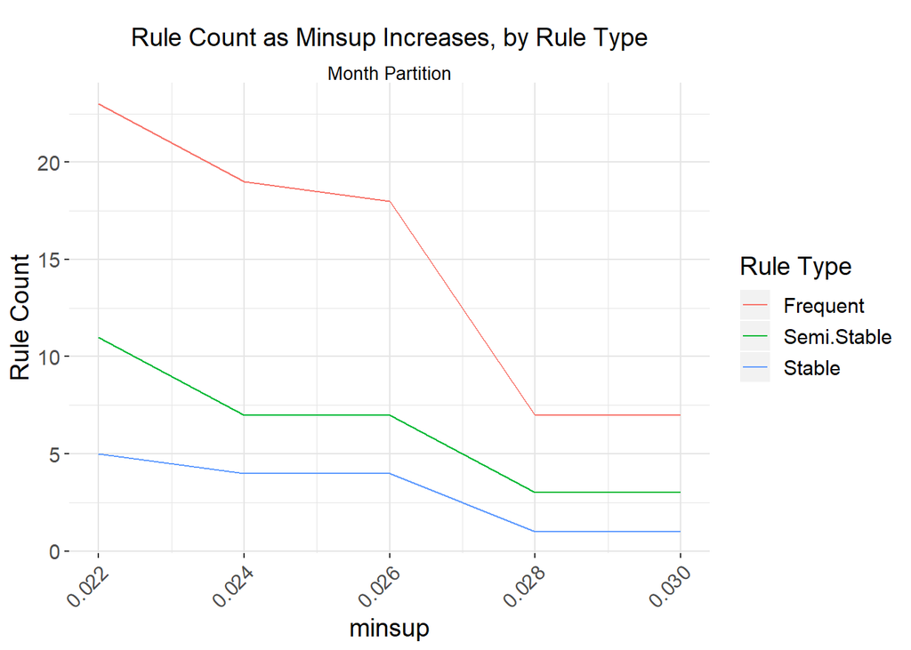

```r
# Plot # of rules by minsup
minsups <- c(.022,.024,.026,.028,.03)
rule_type_counts_month <- get_rule_type_counts(minsups, df_month, minconf, confidence_val)

ggplot(rule_type_counts_month) + geom_line(aes(x=minsup,y=`Rule Count`,color=`Rule Type`)) + labs(title="Rule Count as Minsup Increases, by Rule Type", subtitle="Month Partition") + my_theme
```

## Stable Rules

The table below shows rules that are stable across all 12 months at minsup = 0.03

21977 = PACK OF 60 PINK PAISLEY CAKE CASES  
21212 = PACK OF 72 RETRO SPOT CAKE CASES

| rule | support | confidence | lift |
| --- | --- | --- | --- |
| {21977} => {21212} | 0.032278 | 0.6080717 | 7.265385 |

## Confidence Interval for stable rules

For the stable rules found, we can plot their support confidence intervals by month to show that they are, in fact, stable.

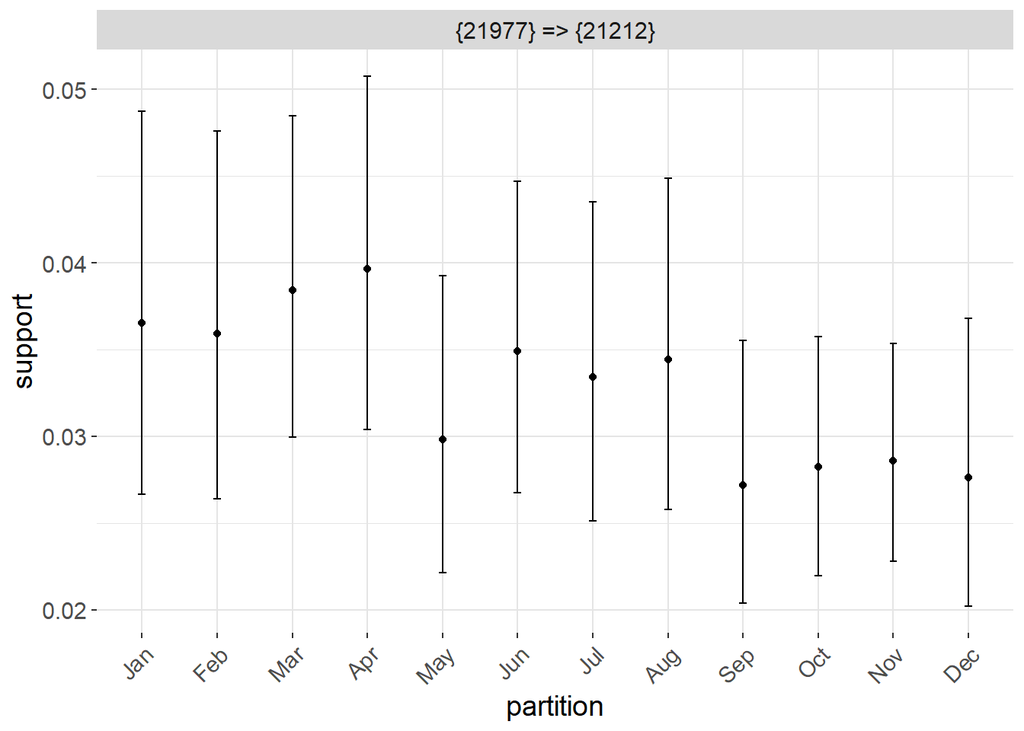